# MALD_EDA

In this notebook, I load up the MALD data and play around with it.

First, let’s import the relevant packages.

```r
library('tidyverse')
```

Now, let’s load the data.

First, I load the item data.

```r
file = 'MALD1_ItemData.Rda'
load(file)
item_data <- items %>%
  as_tibble() %>%
  filter((items$IsWord)) %>%
  select(
    -c(
      Duration,
      WAV,
      StressPattern,
      StressCat,
      Pronunciation,
      IsWord,
      POS,
      AllPOS,
      OrthUP,
      OrthND,
      FreqCOCA,
      FreqGoogle,
      OrthLev,
      NumMorphs,
      Dbet
    )
  ) %>%
  rename(
    syllabic_length = NumSylls,
    phonemic_length = NumPhones,
    degree = PhonND,
    uniqueness_point = PhonUP,
    lev_dist = PhonLev
  )

item_data
```

| Item | syllabic_length | phonemic_length | degree | FreqSUBTLEX | FreqCOCAspok | uniqueness_point | lev_dist |
| --- | --- | --- | --- | --- | --- | --- | --- |
| a | 1 | 1 | 79 | 1041179 | 1259642 | 2 | 5.975207 |
| aback | 2 | 4 | 8 | 15 | 71 | 4 | 5.984128 |
| abandon | 3 | 7 | 2 | 413 | 414 | 8 | 6.689396 |
| abandoned | 3 | 8 | 2 | 678 | 1028 | 8 | 7.340938 |
| abandoning | 4 | 9 | 0 | 86 | 156 | 8 | 8.034292 |
| abandonment | 4 | 11 | 1 | 49 | 73 | 12 | 9.685060 |
| abash | 2 | 4 | 4 | 0 | 2 | 5 | 6.078761 |
| abated | 3 | 6 | 6 | 4 | 20 | 6 | 6.366878 |
| abbey | 2 | 3 | 57 | 162 | 281 | 4 | 6.001562 |
| abbot | 2 | 4 | 13 | 43 | 21 | 5 | 5.746372 |

[output cut: 990 more lines]

Now I load the response data.

```r
load('MALD1_ResponseData.Rda')
response_data <-
  rd %>%
  filter(
    (substr((rd$List),0,5) == 'words') & (rd$ACC == TRUE)
  ) %>%
  select(
    -c(
      Experiment,
      ExperimentRunID,
      Subject,
      List,
      Session,
      ACC,
      WordRunLength
    )
  ) %>%
  group_by(Item) %>%
  summarise(response_time = mean(RT))

response_data
```

|  | Item | response_time |
| --- | --- | --- |
| 1 | a | 1176.0000 |
| 2 | aback | 1086.6667 |
| 3 | abandon | 793.4000 |
| 4 | abandoned | 877.7500 |
| 5 | abandoning | 981.5000 |
| 6 | abandonment | 1068.5000 |
| 7 | abash | 950.7500 |
| 8 | abated | 1004.0000 |
| 9 | abbey | 945.0000 |
| 10 | abbot | 920.0000 |

[output cut: 990 more lines]

Now I join them together.

```r
data_joined <-
  left_join(
    x = item_data,
    y = response_data,
    by = 'Item'
  ) %>%
  drop_na()
```

Now I clean the outliers.

```r
data_cleaned <- data_joined[
  (data_joined$response_time < quantile(data_joined$response_time,.999) &
     data_joined$response_time > quantile(data_joined$response_time,.0001)),
  ]
```

Let’s make some plots.

Note that response_time approaches normality in linear-log space.

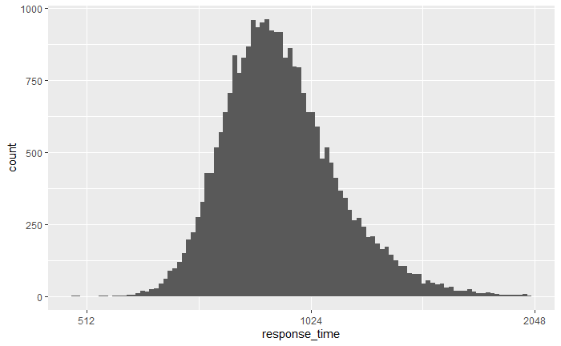

```r
data_cleaned %>%
  ggplot(mapping = aes(x = response_time)) +
  geom_histogram(bins = 100) +
  scale_x_continuous(
    trans='log2',
    breaks = 2 ^ c(9:11)
  )
```

Let’s compare the frequency data. Note that they are linear in log-log space.

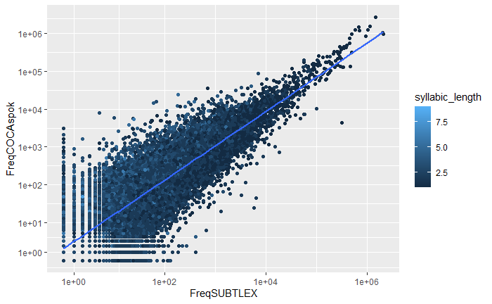

```r
data_cleaned %>%
  ggplot(
    mapping = aes(
      x = FreqSUBTLEX,
      y = FreqCOCAspok,
      color = syllabic_length
      )
  ) +
  geom_point() +
  geom_smooth(method = 'lm',formula = y ~ x) +
  scale_x_continuous(
    trans='pseudo_log',
    breaks = 10 ^ (2 * c(0:5))
    ) +
  scale_y_continuous(
    trans='pseudo_log',
    breaks = 10 ^ c(0:6)
  )
```

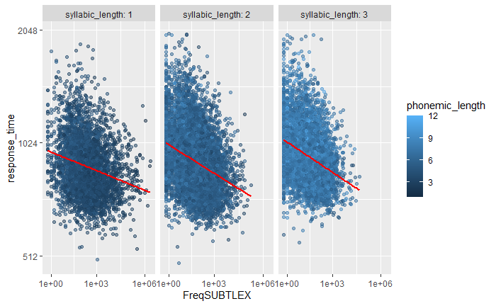

```r
data_cleaned[data_cleaned$syllabic_length <= 3,] %>%
  ggplot(
    mapping = aes(
        x = FreqSUBTLEX,
        y = response_time,
        color = phonemic_length
      )
    ) +
  facet_wrap(
    ~syllabic_length,
    labeller = 'label_both'
    ) +
  geom_point(alpha = .5) +
  geom_smooth(
    method = 'lm',
    color = 'red',
    formula = y ~ x,
    se = FALSE
  ) +
  scale_x_continuous(
    trans='pseudo_log',
    breaks = 10 ^ (3 * c(0:5))
    ) +
  scale_y_continuous(trans='log2')
```

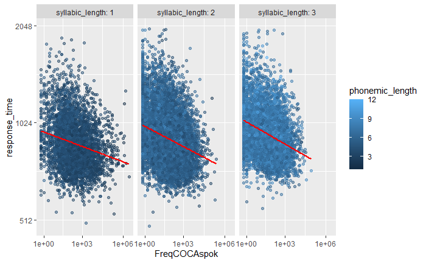

```r
data_cleaned %>%
  filter(syllabic_length <= 3) %>%
  ggplot(
    mapping = aes(
        x = FreqCOCAspok,
        y = response_time,
        color = phonemic_length
      )
    ) +
  facet_wrap(
    ~syllabic_length,
    labeller = 'label_both'
    ) +
  geom_point(alpha = .5) +
  geom_smooth(
    method = 'lm',
    color = 'red',
    formula = y ~ x,
    se = FALSE
  ) +
  scale_x_continuous(
    trans='pseudo_log',
    breaks = 10 ^ (3 * c(0:5))
    )  +
  scale_y_continuous(trans='log2')
```

Note the striking similarity. These corpora are reflecting similar information.

So, I’m creating a new column that contains the total count in both corpora.

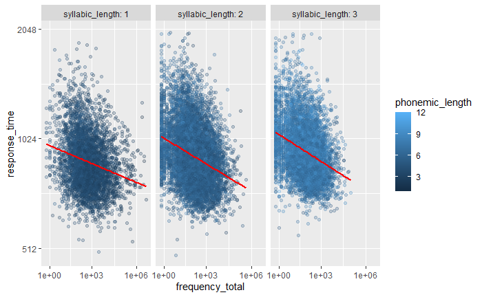

```r
data_cleaned$frequency_total <- data_cleaned$FreqSUBTLEX + data_cleaned$FreqCOCAspok

data_cleaned %>%
  filter(syllabic_length <= 3) %>%
  ggplot(
    mapping = aes(
        x = frequency_total,
        y = response_time,
        color = phonemic_length
      )
    ) +
  scale_x_continuous(
    trans='pseudo_log',
    breaks = 10 ^ (3 * c(0:5))
    )  +
  scale_y_continuous(trans='log2') +
  facet_wrap(
    ~syllabic_length,
    labeller = 'label_both'
    ) +
  geom_point(alpha = .25) +
  geom_smooth(
    method = 'lm',
    color = 'red',
    formula = y ~ x,
    se = FALSE
  )
```

Let’s compare the distributions.

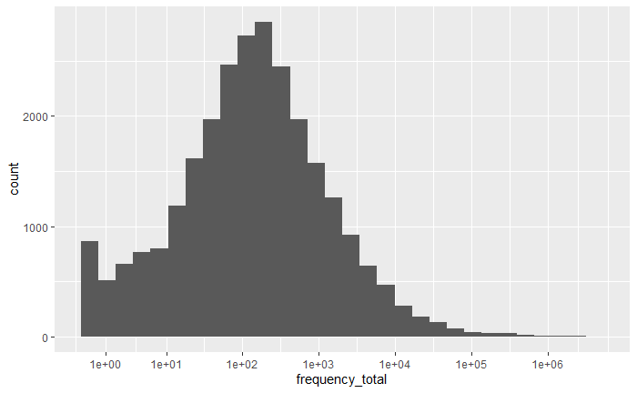

```r
data_cleaned %>%
  ggplot(mapping = aes(x = frequency_total)) +
  geom_histogram(bins = 30) +
  scale_x_continuous(
    trans='pseudo_log',
    breaks = 10 ^ c(0:6)
    )
```

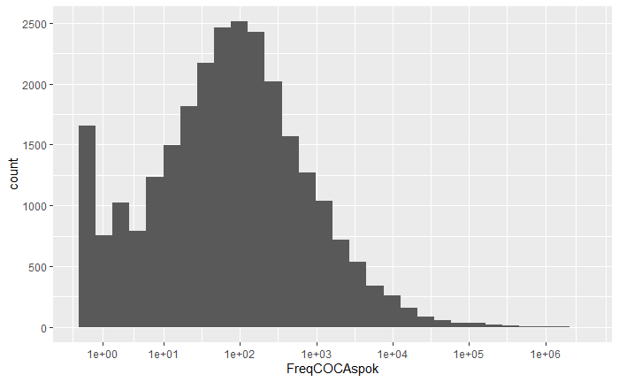

```r
data_cleaned %>%
  ggplot(mapping = aes(x = FreqCOCAspok)) +
  geom_histogram(bins = 30) +
  scale_x_continuous(
    trans='pseudo_log',
    breaks = 10 ^ c(0:6)
    )
```

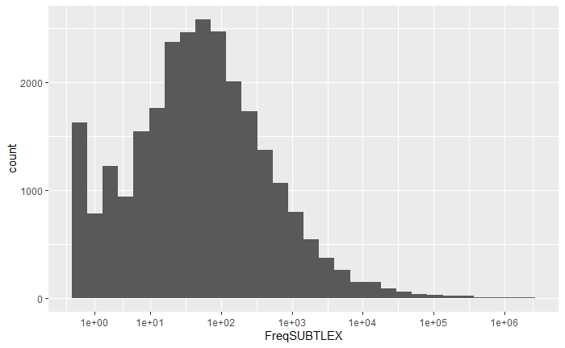

```r
data_cleaned %>%
  ggplot(mapping = aes(x = FreqSUBTLEX)) +
  geom_histogram(bins = 30) +
  scale_x_continuous(
    trans='pseudo_log',
    breaks = 10 ^ c(0:6)
    )
```

The frequency_total distribution best approximates normality. It will therefore be used going forward.

Further, our analysis will focus on words with three or fewer syllables.

```r
data_cleaned_ms <- data_cleaned %>% filter(syllabic_length == 1) #monosyllabic
data_cleaned_bs <- data_cleaned %>% filter(syllabic_length == 2) #bisyllabic
data_cleaned_ts <- data_cleaned %>% filter(syllabic_length == 3) #trisyllabic

data_by_syllable <- list(data_cleaned_ms,data_cleaned_bs,data_cleaned_ts)
```

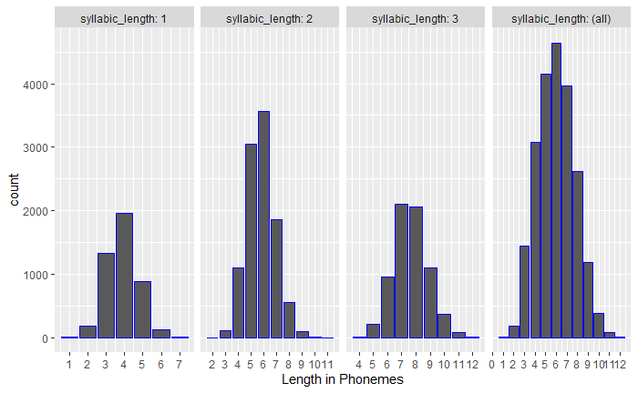

```r
data_cleaned[data_cleaned$syllabic_length <= 3,] %>%
  ggplot(
    mapping = aes(
      x = phonemic_length
      )
  ) +
  facet_grid(
    ~ syllabic_length,
    scales = 'free_x',
    margins = TRUE,
    labeller = label_both
    ) +
  geom_bar(
    colour = 'blue'
    ) +
  scale_x_continuous(
    breaks = 0:12,
    name = 'Length in Phonemes'
    )
```

Within a syllable-length, phonemic length is distributed roughly normally.

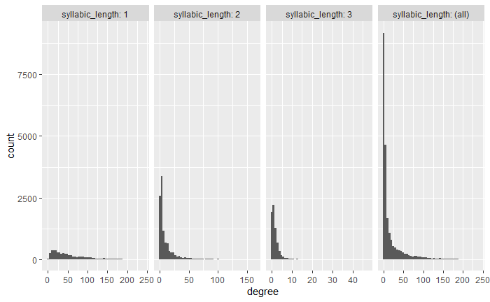

```r
data_cleaned %>%
  filter(syllabic_length <= 3) %>%
  ggplot(mapping = aes(x = degree)) +
  facet_grid(
    ~ syllabic_length,
    scales = 'free',
    labeller = label_both,
    margins = TRUE
    ) +
  geom_histogram(bins = 50)
```

OK, I have no idea what to do with that. Vitevitch (2008) suggests the summation could be fit by a truncated power law. I don’t really know how to do that though. So…

Let’s look at its effect on processing?

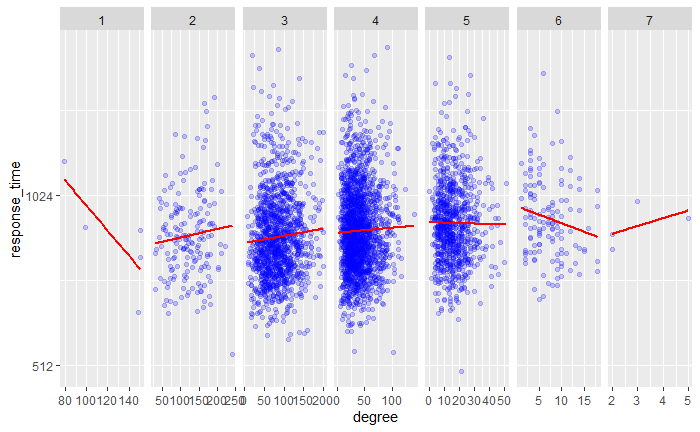

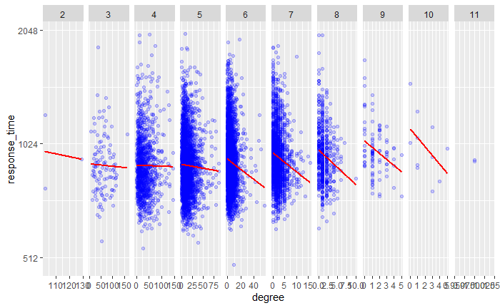

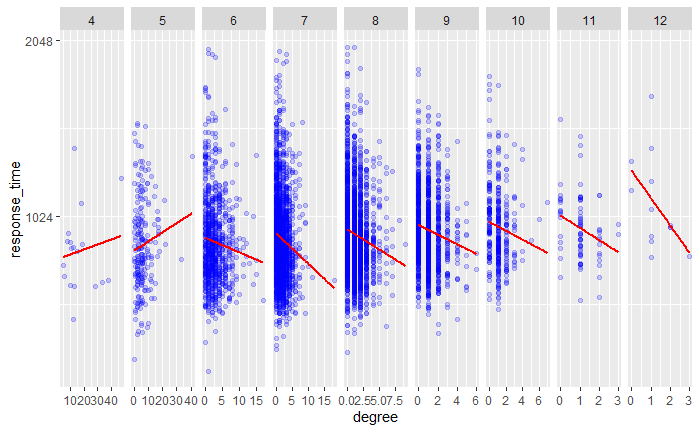

```r
deg_effect <- function(input_data) input_data %>%
  ggplot(
    mapping = aes(
        x = degree,
        y = response_time
      )
    ) +
  scale_y_continuous(trans='log2') +
  facet_grid(
    ~phonemic_length,
    scales = 'free_x'
  ) +
  geom_point(
    color = 'blue',
    alpha = .2
  ) +
  geom_smooth(
    method = 'lm',
    color = 'red',
    formula = y ~ x,
    se = FALSE
  )

lapply(
  X = data_by_syllable,
  FUN = deg_effect
)
```

Hmm. At first glance, that looks like degree facilitates processing. However, the literature suggests this is not correct.

That made me think maybe degree is being confounded with something else. Frequency is the obvious bet.

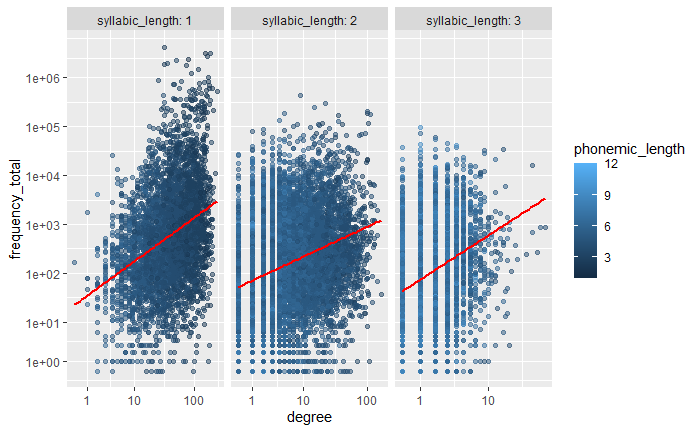

```r
data_cleaned %>%
  filter(syllabic_length <= 3) %>%
  ggplot(
    mapping = aes(
        x = degree,
        y = frequency_total,
        color = phonemic_length
      )
    ) +
  scale_x_continuous(
    trans='pseudo_log',
    breaks = 10 ^ c(0:3)
    )  +
  scale_y_continuous(
    trans='pseudo_log',
    breaks = 10 ^ c(0:8)
    ) +
  facet_wrap(
    ~syllabic_length,
    labeller = 'label_both',
    scales = 'free_x'
    ) +
  geom_point(alpha = .5) +
  geom_smooth(
    method = 'lm',
    color = 'red',
    formula = y ~ x,
    se = FALSE
    )
```

Yep, degree is positively correlated with frequency in log-log space. So, what do I do from here?

Some mysteries:

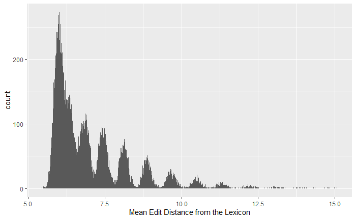

```r
data_cleaned %>%
  ggplot(mapping = aes(x = lev_dist)) +
  geom_histogram(bins = 1000) +
  scale_x_continuous(
    name = 'Mean Edit Distance from the Lexicon'
    )
```

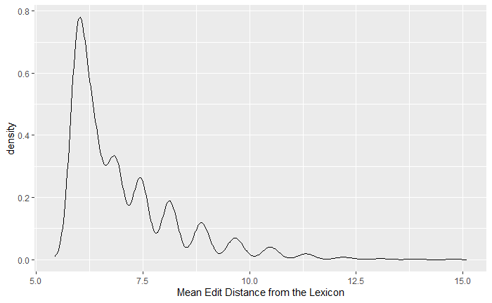

```r
data_cleaned %>%
  ggplot(mapping = aes(x = lev_dist)) +
  geom_density() +
  scale_x_continuous(
    name = 'Mean Edit Distance from the Lexicon'
    )
```

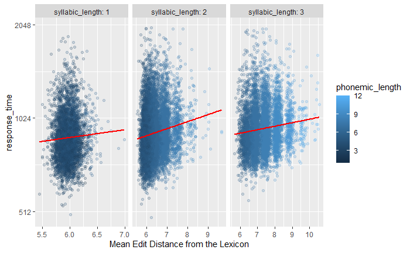

```r
levd_effect <- function(input_data) input_data %>%
  ggplot(
    mapping = aes(
        x = lev_dist,
        y = response_time,
        color = phonemic_length
      )
    ) +
  facet_grid(
    ~syllabic_length,
    scales = 'free',
    labeller = 'label_both'
  ) +
  geom_point(
    alpha = .2
  ) +
  geom_smooth(
    method = 'lm',
    color = 'red',
    formula = y ~ x,
    se = FALSE
  ) +
  scale_y_continuous(
    trans='log2'
  ) +
  scale_x_continuous(
    name = 'Mean Edit Distance from the Lexicon'
  )

levd_effect(
  data_cleaned[data_cleaned$syllabic_length <= 3,]
)
```

Might I need multi-level modeling for phonemic length?

No idea what to even do here:

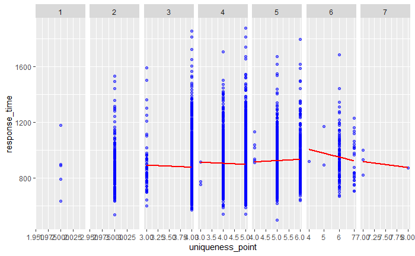

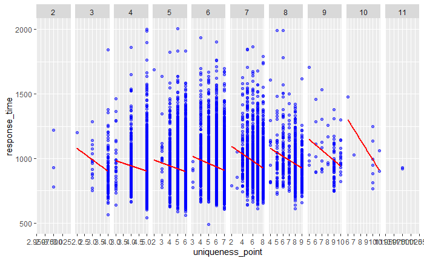

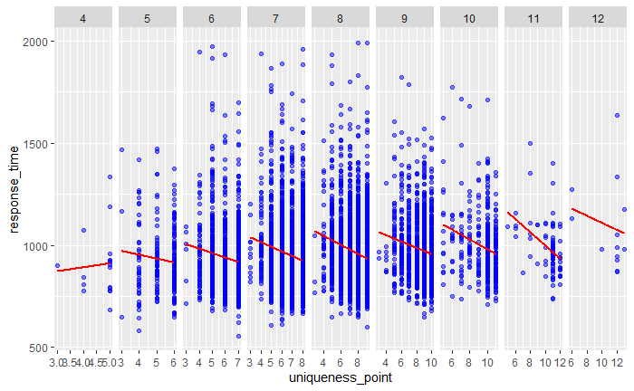

```r
up_effect <- function(input_data) input_data %>%
  ggplot(
    mapping = aes(
        x = uniqueness_point,
        y = response_time
      )
    ) +
  facet_grid(
    ~phonemic_length,
    scales = 'free'
  ) +
  geom_point(
    color = 'blue',
    alpha = .5
  ) +
  geom_smooth(
    method = 'lm',
    color = 'red',
    formula = y ~ x,
    se = FALSE
  )

lapply(
  X = data_by_syllable,
  FUN = up_effect
)
```